# Portfolio_5

Lindley Slipetz

3/2/2021

This project is looking at the representation of women in Philosophy through being professors and publishing in top journals. I have two data sets. One is the breakdown of professorship by gender at the top universities for Philosophy in the US. Another is a breakdown of article authorship by gender. Unfortunately, I’m going to have to leave the non-binary data from the professor data out of the analysis because the publication dataset only includes binary genders.

We’ll start by loading in packages.

```r
library(tidyverse)
#install.packages("pdftools")
library(pdftools)
library(readxl)
#install.packages("anchors")
library(anchors)
#install.packages("textclean")
library(textclean)
```

Now, let’s load the data. For our datasets, we have an excel spreadsheet and a PDF…so this should be fun. (if you’re wondering what kind of monsters would save their data as a PDF, the answer is philosophers).

```r
faculty <- read_excel("C:\\Users\\Owner\\Google Drive\\DataScience\\Portfolio_5\\Portfolio_5\\data\\faculty.xlsx", sheet = 1)
publishing <- pdf_text("C:\\Users\\Owner\\Google Drive\\DataScience\\Portfolio_5\\Portfolio_5\\data\\publishing.pdf")
```

So, the excel data is all nice and tidy, but the PDF data…well that’s going to take some work. I’m going to follow the method from [PDF to dataframe] (https://medium.com/swlh/the-adventure-of-pdf-to-data-frame-in-r-f90609035600) We’ll start by separating by new lines.

```r
publishing <- publishing %>%
  str_split("\n")
```

There’s some superfluous headers and footers, so we’re going to delete those. The first page is unique, so we’ll handle its header separately.

```r
publishing[[1]] <- publishing[[1]][-1:-29]
for(i in 1:52){
   a <- length(publishing[[i]])
   b <- a-1
   publishing[[i]] <- publishing[[i]][-b:-a]
}
```

Eventually we’re going to need this to be separated into columns. We’re going to achieve that in an unintuitive way. Let’s smoosh it together!

```r
publishing <- publishing %>%
  str_squish()
```

Now we’re going to separate the lines out.

```r
publishing <- unlist(publishing) %>%
  strsplit(split= "\\,\\s\\\"")
```

There’s still some extra symbols, so let’s get rid of those.

```r
for(i in 1:length(publishing)) {
   publishing[[i]][1] <- publishing[[i]][1] %>%
    stringr::str_extract("(?<=c[:punct:]\\\").*")
}
for(i in 1:length(publishing)) {
  for(j in 1:length(publishing[[i]])) {
    publishing[[i]][j] <- publishing[[i]][j] %>%
      stringr::str_extract(".*(?=\")")
    }
}
for(i in 1:length(publishing)) {
  for(j in 1:length(publishing[[i]])) {
    publishing[[i]][j] <- publishing[[i]][j] %>%
      str_remove("\\\\r")
    }
}
```

Okay, now we’re going to extract the names of the journals. The way that’s suggested to do it won’t work because of the structure of my dataset, so we’ll need to be creative. This took me entirely too long, but we got it!

```r
names_ex = list() #define a list to save extracted words to
for(i in 1:length(publishing)) { #loop through lists
  for(j in 1:length(publishing[[i]])){ #loop through lines of lists
  words <- publishing[[i]] %>% str_extract("\\D+")
  words_df <- data.frame(words) #turns into data frame for list
  names_ex[[i]] <- words_df #save
  journal_names <- dplyr::bind_rows(names_ex)
  }
}
journal_names <- as.data.frame(journal_names[!apply(is.na(journal_names) | journal_names == " ", 1, all),])

colnames(journal_names) <- "words"
```

You would think we’d be done here, but we’re not. Some of the journal names printed on two lines (ugh!). So, now we’re going to have to go in and make them one line.

```r
rev_journal <- journal_names %>%
  mutate(journal = case_when(
    journal_names$words == "Philosophical Review " ~ "Philosophical Review",
    journal_names$words == "Journal of Philosophy " ~ "Journal of Philosophy",
    journal_names$words == "Nous " ~ "Nous",
    journal_names$words == "Mind " ~ "Mind",
    journal_names$words == "Philosophy & " ~ "Philosophy & Phenomenological",
    journal_names$words == "Philosophy & Phenomenological " ~ "Philosophy & Phenomenological",
    journal_names$words == "Ethics " ~ "Ethics",
    journal_names$words == "Philosophical Studies " ~ "Philosophical Studies",
    journal_names$words ==  "Australasian Journal of Philosophy " ~     "Australasian Journal of Philosophy",
    journal_names$words ==  "Australasian Journal of Philosophy" ~      "Australasian Journal of Philosophy",
    journal_names$words == "Australasian Journal of " ~ "Australasian Journal of Philosophy",
    journal_names$words == "Philosopher's Imprint " ~ "Philosopher's Imprint",
    journal_names$words == "Analysis " ~ "Analysis",
    journal_names$words == "Philosophical Quarterly " ~ "Philosophical Quarterly",
    journal_names$words == "American Philosophical Quarterly " ~ "American Philosophical Quarterly",
    journal_names$words == "American Philosophical " ~ "American Philosophical Quarterly",
    journal_names$words == "Philosophy & Public Affairs " ~ "Philosophy & Public Affairs",
    journal_names$words == "Philosophy of Science " ~ "Philosophy of Science",
    journal_names$words == " Philosophy of Science" ~ "Philosophy of Science",
    journal_names$words == "British Journal for the Philosophy " ~
      "British Journal for the Philosophy",
    journal_names$words ==  "Synthese " ~ "Synthese",
    journal_names$words == "Proceedings of the Aristotelian" ~ "Proceedings of the Aristotelian",
    journal_names$words == "Proceedings of the " ~ "Proceedings of the Aristotelian",
    journal_names$words == "Erkenntnis " ~ "Erkenntnis",
    journal_names$words == "Canadian Journal of " ~ "Canadian Journal of Philosophy",
    journal_names$words == "Canadian Journal of Philosophy" ~ "Canadian Journal of Philosophy",
    journal_names$words == "Journal of the History of Philosophy" ~ "Journal of the History of Philosophy",
    journal_names$words == "Journal of the History of " ~ "Journal of the History of Philosophy",
    journal_names$words == "Journal of Philosophical " ~ "Journal of Philosophical Logic",
    journal_names$words == "Journal of Philosophical Logic" ~ "Journal of Philosophical Logic",
    journal_names$words == "Mind & Language " ~ "Mind & Language",
    journal_names$words == "Pacific Philosophical " ~ "Pacific Philosophical Quarterly",
    journal_names$words == "Pacific Philosophical Quarterly" ~ "Pacific Philosophical Quarterly",
    journal_names$words == "European Journal of " ~ "European Journal of Philosophy",
    journal_names$words == "European Journal of Philosophy" ~ "European Journal of Philosophy",
   journal_names$words == "British Journal for the " ~ "British Journal for the History of Philosophy",
   journal_names$words == "British Journal for the History" ~ "British Journal for the History of Philosophy"

  ))
rev_journal <- na.omit(rev_journal)
```

Okay, now time to handle the digit data.

```r
numbers_ex = list()
k=1
for(i in 1:length(publishing)) {
  for(j in 1:length(publishing[[i]])){
    numbers <- publishing[[i]][j] %>% str_extract("[:digit:]+.*")
    numbers_df <- data.frame(numbers)
    while(k <= 20000) {
    numbers_ex[[k]]<- numbers_df
    k <- k+1
    break
    }
  }
  NH_numbers <- dplyr::bind_rows(numbers_ex)
}
```

Guess what?! It’s a mess! Well start by separating the numbers.

```r
NH_numbers %>%
  separate(numbers, c("A","B","C","D","E","F","G","H","I","J"), sep="\\s") -> NH_numbers
```

There are a bunch of random words which specify specific issues. We don’t need those, so we’ll delete them.

```r
for(i in 1:nrow(NH_numbers))
for(j in 1:ncol(NH_numbers)) {
    NH_numbers[i,j] <- NH_numbers[i,j] %>%
      str_remove("^\\D+")
    }
```

NH_numbers <- as.data.frame(na.omit(NH_numbers[,1]), stringsAsFactors = FALSE)

Now we need to get the data in the same row. I’m going to go an extreme route because I can’t think of any other way to do it. I’m going to start rebuilding the numerical data frame by making a column of 4 digit numbers.

```r
new_numeric <- data.frame("year", stringsAsFactors = FALSE)
for(i in 1:nrow(NH_numbers)){
  if(is.na(NH_numbers[i,1]) == FALSE){
  if(str_detect(NH_numbers[i,1], "^[0-9]{4}$") == TRUE){
    new_numbers <- str_extract(NH_numbers[i,1], "^[0-9]{4}$")
    new_numeric[nrow(new_numeric) + 1, ] <- new_numbers
}
  }
    }
```

Okay, now we have all of the years. Let’s clean up this dataframe. (not sure if I need this)

```r
new_numeric <- na.omit(new_numeric)
new_numeric <- new_numeric[-1,]
```

Well, now we have more journal names than numeric data…so that’s great! I’m pretty confident about the number of numeric values, so there seems to be 64 extra journal names. I’m going to go back to how the journal names were created and see if there’s anything wrong with the code.

I’m going to try something here. In the console, I’m counting how many occurences of each journal there are in the original document with “sapply(gregexpr(”\b…\b“, publishing), function(x) sum(x > 0))”. I’m also looking for the number of 4 digit numbers (the years).

Okay, I went back and fiddled with the code. We have 3709 journals and 3646 years…so we’re getting closer!

I basically manually counted the journal names and found that there are 3682. I’ve tried everything I can think of: count from code, count in console with code, and manual count. No matter what I do I can’t get them to agree. I’ve been at this for a while, and I think it’s time to throw in the towel. We’ll just count this as my failed attempt at reading in a PDF. It was a useful exercise in that I think with a better dataset I’m now equipped to successfully read PDFs.

Now, I’m just going to look at the faculty dataset. We’ll be looking at the representation of women in philosophy faculty positions. As a warm up, we’re just going to look at Joey’s department, University of Washington. Keep in mind that this data is out of data and they’ve hired another woman since then. First I’m going to change variable names.

```r
faculty <- faculty %>%
  subset(select = c("School", "Total % Women 2019", "% TT Women 2019", "% Full Women 2019", "% Assoc Women  2019", "% Assist Women 2019", "%  Emer  Women  2019")) %>%
  rename(
    Total = "Total % Women 2019",
    TT = "% TT Women 2019",
    Full = "% Full Women 2019",
    Associate = "% Assoc Women  2019",
    Assistant = "% Assist Women 2019",
    Emeritus = "%  Emer  Women  2019"
    )
```

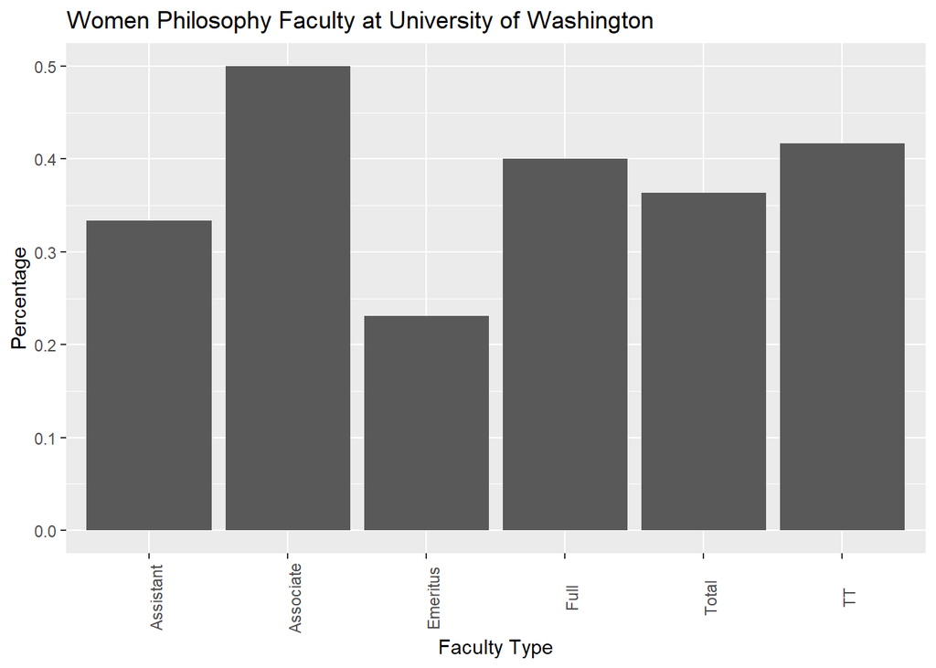

```r
UWa <- faculty %>%
  subset(School == "University of Washington", select = c("Total", "TT", "Full", "Associate", "Assistant", "Emeritus"))
UWa %>%
  gather("Faculty", "Value") %>%
  ggplot(aes(Faculty, Value)) +
  geom_bar(position = "dodge", stat = "identity") +
  theme(axis.text.x = element_text(angle = 90)) +
  labs(y = "Percentage", x = "Faculty Type", title = "Women Philosophy Faculty at University of Washington")
```

So, I think UW is an anomaly in Philosophy (and I think that’s well known in the field). Notice their percentage of Associate Professors who are women is almost 50%. Given that only about 30% of Philosophy PhDs are women, that’s a remarkable number. They also have a high percentage of women who are full profesors. Their total number of women is more in line with the degree-granting percentage. Overall, they show a good representation of women.

Now, I want to look at a school that does Philosophy of Science. As a former Philosopher of Science, I can tell you that the representation of women in Philosophy of Science is even worse than Philosophy generally (and Philosophy generally has a problem with gender representation). So, let’s look at Carnegie Mellon.

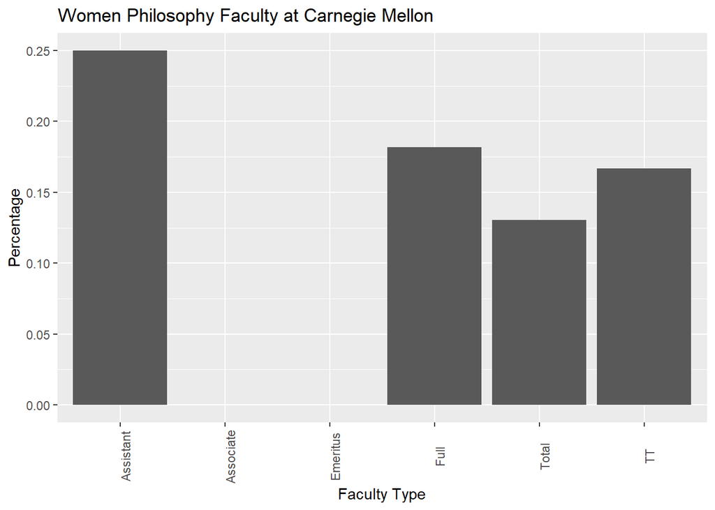

```r
CM <- faculty %>%
  subset(School == "Carnegie-Mellon University", select = c("Total", "TT", "Full", "Associate", "Assistant", "Emeritus"))
CM %>%
  gather("Faculty", "Value") %>%
  ggplot(aes(Faculty, Value)) +
  geom_bar(position = "dodge", stat = "identity") +
  theme(axis.text.x = element_text(angle = 90)) +
  labs(y = "Percentage", x = "Faculty Type", title = "Women Philosophy Faculty at Carnegie Mellon")
```

So, yeah…Carnegie Mellon doesn’t look too good for the representation of women. Their total percentage is around 13% as opposed to UW’s 35+%. Their highest category is Assistant Professors, which I guess tells us they’re trying to do something about. There seem to be no women who are Associate Professors or Emeritus, which is concerning. Overall, this seems representative of Philosophy of Science.

Now, for fun, let’s look at one of my old departments: University of Wisconsin (I can’t look at UCI because my department was actually separate from the Philosophy department, so there’s no separate data for that).

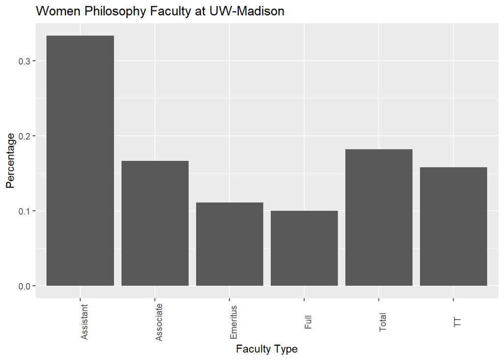

```r
UW <- faculty %>%
  subset(School == "University of Wisconsin, Madison", select = c("Total", "TT", "Full", "Associate", "Assistant", "Emeritus"))
UW %>%
  gather("Faculty", "Value") %>%
  ggplot(aes(Faculty, Value)) +
  geom_bar(position = "dodge", stat = "identity") +
  theme(axis.text.x = element_text(angle = 90)) +
  labs(y = "Percentage", x = "Faculty Type", title = "Women Philosophy Faculty at UW-Madison")
```

Like Carnegie Mellon, UW has a high number of Assistant Professors, so at least they’re moving in the right direction. There are very few women who are full professors (actually there is only one. Her name is Paula Gottlieb, and she’s great!).The total number of women faculty is quite low, under 20%. But at least we’re better than Carnegie Mellon!

I have too many data points to do one bar graph. So, I’m going to split them by rank

```r
faculty$rank <- 1:nrow(faculty)
faculty <- faculty %>%
  mutate(rank_group = case_when(
    rank < 21 ~ "1-20",
    20 < rank & rank < 41 ~ "20-40",
    40 < rank & rank < 61 ~ "41-60",
    60 < rank & rank < 81 ~ "61 - 80",
    80 < rank & rank < 100 ~ "81 -100"
  ))
```

I tried to get a graph of everyone with facet_wrap, but it was still a total mess. I’m going to limit my analysis to the top 20 and bottom 18.

Here’s an attempt at a graph. CUNY’s name is too long, so I need to fix it

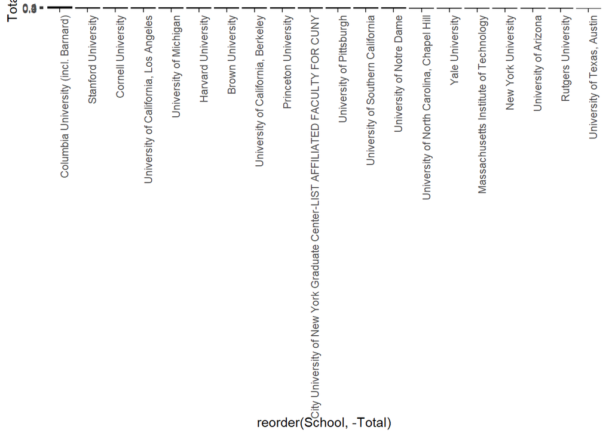

```r
faculty %>%
  subset(rank_group == "1-20", select = c(School, Total)) %>%
  ggplot(aes(x = reorder(School, -Total), y = Total)) +
  geom_bar(stat="identity",fill='black') +
  theme(axis.text.x=element_text(angle=90, hjust=1))
```

```r
faculty$School[faculty$School == "City University of New York Graduate Center-LIST AFFILIATED FACULTY FOR CUNY"] <- "CUNY"
```

Okay, let’s try the graph again.

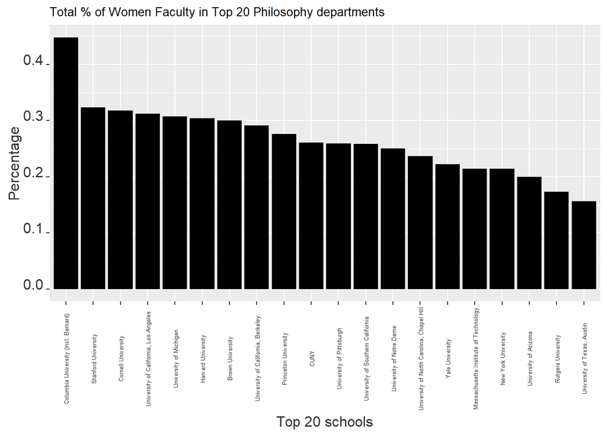

```r
faculty %>%
  subset(rank_group == "1-20", select = c(School, Total)) %>%
  ggplot(aes(x = reorder(School, -Total), y = Total)) +
  geom_bar(stat="identity",fill='black') +
  theme(axis.text.x = element_text(color = "grey20", size = 5, angle = 90, hjust = .5, vjust = .5, face = "plain"),
        axis.text.y = element_text(color = "grey20", size = 12, angle = 0, hjust = 1, vjust = 0, face = "plain"),
        axis.title.x = element_text(color = "grey20", size = 12, angle = 0, hjust = .5, vjust = 0, face = "plain"),
        axis.title.y = element_text(color = "grey20", size = 12, angle = 90, hjust = .5, vjust = .5, face = "plain"),
        plot.title = element_text(size=10)) +
  labs(x = "Top 20 schools", y = "Percentage", title = "Total % of Women Faculty in Top 20 Philosophy departments")
```

Columbia is by far the leader in hiring women. University of Texas-Austin needs some work (which is not surprising given the reputation the department has). There’s a cluster of universities around 30% and another cluster around 20%. I’m kind of surprised about Rutgers because it’s the number 2 program in the country (3 in the world). I would have hoped they’d do better.

Let’s look at breakdowns of the best department and the worst department in the top 20.

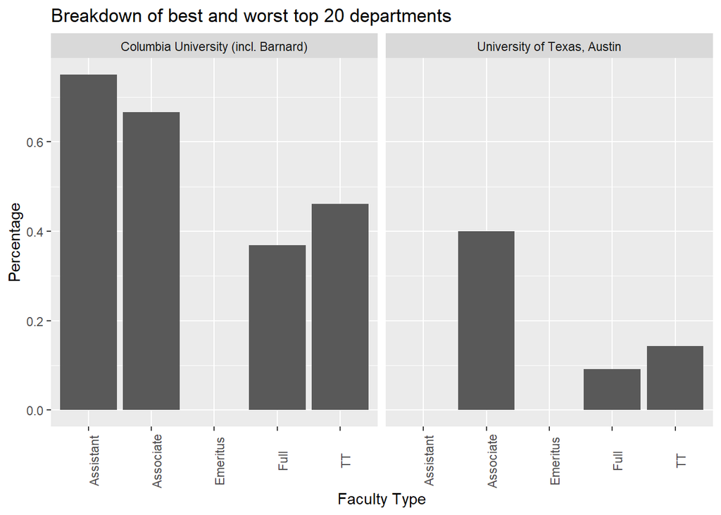

```r
top_compare <- faculty %>%
  subset(School == "Columbia University (incl. Barnard)" | School == "University of Texas, Austin", select = c("School", "TT", "Full", "Associate", "Assistant", "Emeritus"))
top_compare %>%
  gather("Faculty", "Value", -School) %>%
  ggplot(aes(Faculty, Value)) +
  geom_bar(position = "dodge", stat = "identity") +
  theme(axis.text.x = element_text(angle = 90)) +
  facet_wrap(~School) +
  labs(x = "Faculty Type", y = "Percentage", title = "Breakdown of best and worst top 20 departments")
```

Neither school has women who are Emeritus, so it shows they don’t have a history of hiring women. Columbia has super impressive numbers of Assistant and Associate Professors: they’re hiring majority women what?! UT-Austin did fine with Associate Professors, but they have some serious issues with Assistant and Full professors. This is further shown by the low level of TT woman faculty. Let’s look at the bottom schools to see how they fair.

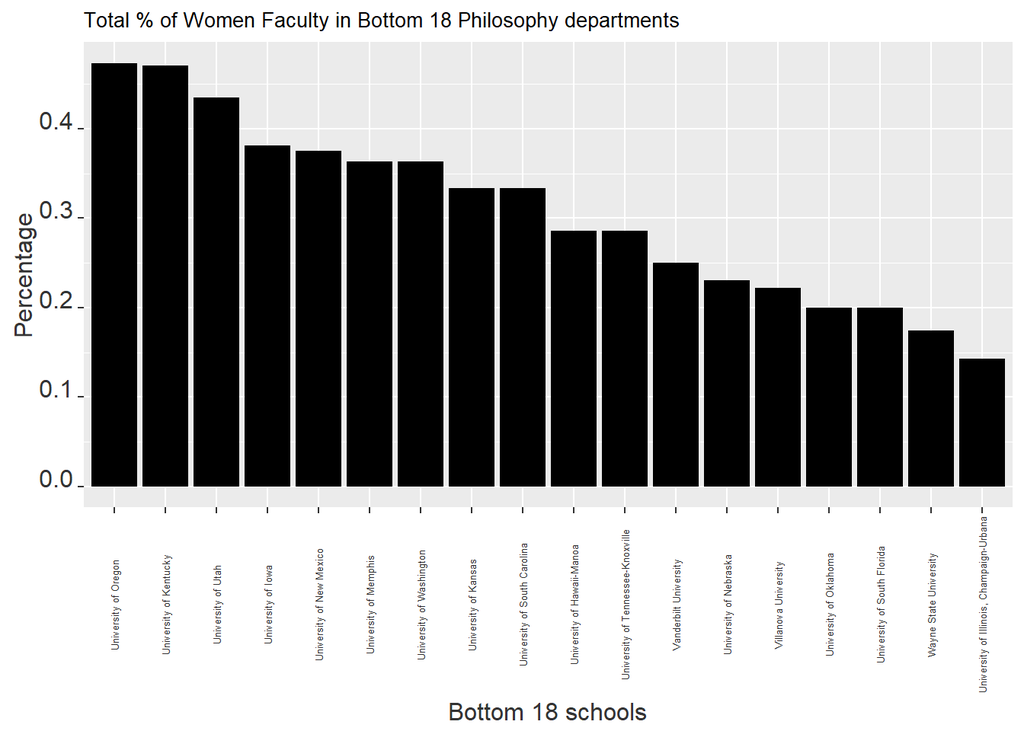

```r
faculty %>%
  subset(rank_group == "81 -100", select = c(School, Total)) %>%
  ggplot(aes(x = reorder(School, -Total), y = Total)) +
  geom_bar(stat="identity",fill='black') +
  theme(axis.text.x = element_text(color = "grey20", size = 5, angle = 90, hjust = .5, vjust = .5, face = "plain"),
        axis.text.y = element_text(color = "grey20", size = 12, angle = 0, hjust = 1, vjust = 0, face = "plain"),
        axis.title.x = element_text(color = "grey20", size = 12, angle = 0, hjust = .5, vjust = 0, face = "plain"),
        axis.title.y = element_text(color = "grey20", size = 12, angle = 90, hjust = .5, vjust = .5, face = "plain"),
        plot.title = element_text(size=10)) +
  labs(x = "Bottom 18 schools", y = "Percentage", title = "Total % of Women Faculty in Bottom 18 Philosophy departments")
```

We can see that University of Oregon is a top school, almost tied with University of Kentucky. U of O makes sense because it’s a Feminist Philosophy heavy department (I wish sub-specialities weren’t gender-specific, but they are). It looks comparable to Columbia. UIUC looks comparable to UT-Austin. Let’s look at the breakdown.

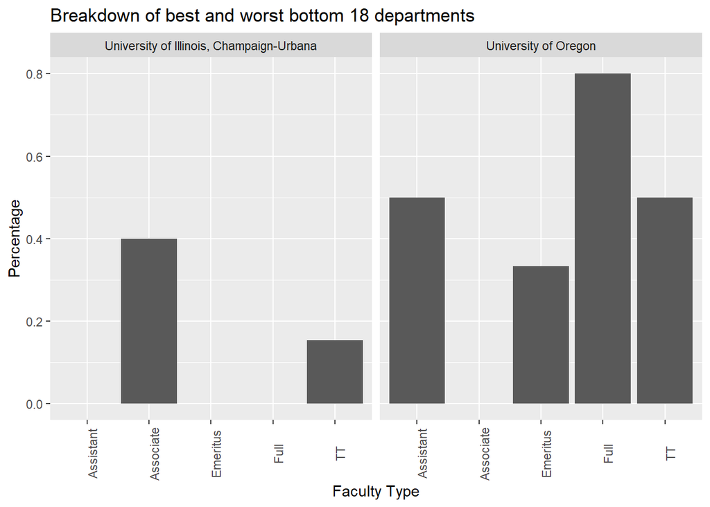

```r
bottom_compare <- faculty %>%
  subset(School == "University of Oregon" | School == "University of Illinois, Champaign-Urbana", select = c("School", "TT", "Full", "Associate", "Assistant", "Emeritus"))
bottom_compare %>%
  gather("Faculty", "Value", -School) %>%
  ggplot(aes(Faculty, Value)) +
  geom_bar(position = "dodge", stat = "identity") +
  theme(axis.text.x = element_text(angle = 90)) +
  facet_wrap(~School) +
  labs(x = "Faculty Type", y = "Percentage", title = "Breakdown of best and worst bottom 18 departments")
```

Wow, so about UIUC: they have no Assistant, Emeritus, or Full woman faculty. I wish I could say that’s why they’re ranked so low, but Philosophers aren’t really bothered by that kind of thing. Now check out UofO’s Full Professors! That is seriously unbelievable. Their tenure track is an even split. Let’s do one last thing. Let’s rank the programs by percentage of TT faculty.

```r
faculty %>%
  arrange(desc(TT))
```

```
## # A tibble: 98 x 9
##    School        Total    TT  Full Associate Assistant Emeritus  rank rank_group
##    <chr>         <dbl> <dbl> <dbl>     <dbl>     <dbl>    <dbl> <int> <chr>
##  1 University o~ 0.381 0.5   0.286     0.8      NA        0        83 81 -100
##  2 University o~ 0.474 0.5   0.8       0         0.5      0.333    90 81 -100
##  3 University o~ 0.435 0.5   0.571     0.286     0.75     0        94 81 -100
##  4 Emory Univer~ 0.476 0.467 0.3       0.75      1        0.4      59 41-60
##  5 Columbia Uni~ 0.448 0.462 0.368     0.667     0.75     0        10 1-20
##  6 University o~ 0.471 0.438 0.167     0.5       0.75     0        85 81 -100
##  7 Indiana Univ~ 0.333 0.429 0.2       1         1        0.214    25 20-40
##  8 SUNY Bingham~ 0.429 0.429 0.5       0.333    NA       NA        69 61 - 80
##  9 University o~ 0.385 0.417 0.2       0.5       0.667    0        46 41-60
## 10 University o~ 0.364 0.417 0.4       0.5       0.333    0.231    95 81 -100
## # ... with 88 more rows
```

There are 3 schools with a 50/50 split: University of Iowa, University of Oregon, and University of Utah. That’s 3% of top 98 programs having an equal number of men and women. I guess that’s not surprising given the stat I gave earlier about only 30% of Philosophy PhDs being women. Still, I think there’s an obvious problem going on.